# Cell-ID Validation

### Consolidation of immune cells

Now, for immune cells. I’m going to remove both myeloid cells and hematopoietic stem/ progenitor cells since they’re ancestors of other cell types that are present here. I’ll also lump thymocytes under lymphoid cells since they’re functionally very similar.

```r
celltype_sampler <- celltype_sampler %>%
  mutate(celltype=if_else(celltype %in% c("Myeloid cells", "Hematopoietic stem cells"), true=NA_character_, false=celltype)) %>%
  mutate(celltype=if_else(celltype == "Thymocytes", true="Lymphoid cells", false=celltype)) %>%
  drop_na()
```

Now, I need to update the dataset to contain even samples from these groups

```r
celltype_subsetter <- celltype_sampler %>%
  select(-n) %>%
  group_by(celltype) %>%
  add_count(celltype)
keepers_rare <- celltype_subsetter %>%
  filter(n <= 5000) %>%
  pull(sample)
keepers_sampled <- celltype_subsetter %>%
  filter(n > 5000) %>%
  slice_sample(n=5000) %>%
  pull(sample)
celltype_subsetter <- celltype_subsetter %>%
  filter(sample %in% c(keepers_rare, keepers_sampled))
```

Now, I’ll do the same thing to validate a classifier based on these revised cell types

```r
fca_subsampled <- fca[,celltype_subsetter$sample]
fca_subsampled$celltype <- celltype_subsetter$celltype

fca_subsampled.dec <- modelGeneVar(fca_subsampled)
hvg.fca_subsampled <- getTopHVGs(fca_subsampled.dec, fdr.threshold=0.1)

fca_subsampled.pca <- prcomp(t(logcounts(fca_subsampled)[hvg.fca_subsampled,]), rank=50)
reducedDims(fca_subsampled) <- list(PCA=fca_subsampled.pca$x)

fca_subsampled <- RunMCA(fca_subsampled, nmcs=50, features=hvg.fca_subsampled)
```

Check the performance of a Cell ID classifier on the dataset it came from (FCA)

```r
# new_signatures <- GetGroupGeneSet(fca_subsampled, group.by="celltype", n.features=100)

new_cellid_enrichments <- RunCellHGT(fca_subsampled, pathways = new_signatures, features=hvg.fca_subsampled, dims = 1:50, n.features=100)
```

```
calculating distance

ranking genes
```

[output not shown]

[output cut: 46 more lines]

[output not shown]

```
33 pathways kept for hypergeometric test out of 33, 0 filtered as less than 10 features was present in the data

calculating features overlap

calculating number of success
```

[output not shown]

```
performing hypergeometric test
```

[output not shown]

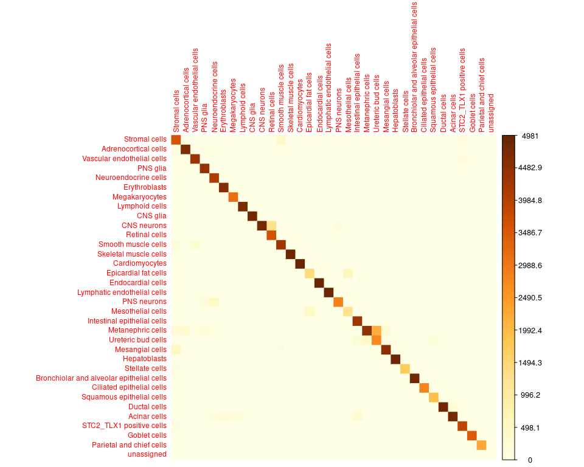

```r
new_cellid_labels <- rownames(new_cellid_enrichments)[apply(new_cellid_enrichments, 2, which.max)]
new_cellid_labels <- ifelse(apply(new_cellid_enrichments, 2, max)>2, yes = new_cellid_labels, "unassigned") #3 unassigned cells here

celltypes_remaining <- c(unique(colData(fca_subsampled)$celltype), "unassigned")
new_confusion <- confusionMatrix(data=factor(new_cellid_labels, levels=celltypes_remaining),
                                 reference = factor(colData(fca_subsampled)$celltype, levels=celltypes_remaining))

corrplot(new_confusion$table, is.corr=F, tl.pos='lt', tl.cex=0.75, method='color')
```

Cell type tree

```r
mca.embedding.subsampled <- reducedDim(fca_subsampled, "MCA")
new_celltype_centroids <- aggregate.Matrix(mca.embedding.subsampled, groupings=fca_subsampled$celltype, fun="mean")

new_dists <- dist(new_celltype_centroids)
hc <- hclust(new_dists)
plot(hc, cex=0.8)
```

[output not shown]

# Visualize MC space

```r
emb <- as_tibble(reducedDim(fca_subsampled, "MCA"), rownames="sample") %>%
  left_join(as_tibble(colData(fca_subsampled)), by="sample")
centroids <- as_tibble(as.matrix(new_celltype_centroids), rownames="celltype")
```

[output not shown]

[figure not shown]

# Visualize distance in terms of hamming distance between cell types

```r
celltypes <- unique(names(new_signatures))
ct_dists <- matrix(nrow=length(celltypes), ncol=length(celltypes))
rownames(ct_dists) <- celltypes
colnames(ct_dists) <- celltypes
for (ct1 in seq_len(length(celltypes))) {
  for (ct2 in seq_len(length(celltypes))) {
    ct_dists[ct1, ct2] = 100 - length(intersect(new_signatures[[ct1]], new_signatures[[ct2]]))
  }
}
hc <- hclust(as.dist(ct_dists), method="average")
plot(hc, cex=0.8)
```

[output not shown]

# Save cell type signatures, highly variable genes, and our filtered object

```r
saveRDS(fca_subsampled, "/project2/gilad/jpopp/ebQTL/data/fca/counts.subsampled.mca_pca_fromhvgs.sce")
save(new_signatures, hvg.fca_subsampled, file="/project2/gilad/jpopp/ebQTL/data/fca/cellid_signatures_and_hvgs.Rdata")
```

## View distances to centroid

```r
fca_subsampled <- readRDS("/project2/gilad/jpopp/ebQTL/data/fca/counts.subsampled.mca_pca_fromhvgs.sce")
load("/project2/gilad/jpopp/ebQTL/data/fca/cellid_signatures_and_hvgs.Rdata")

emb <- as_tibble(reducedDim(fca_subsampled, "MCA"), rownames="sample") %>%
  left_join(as_tibble(colData(fca_subsampled)), by="sample")
gene_emb <- attributes(emb$MCA_1)$genesCoordinates
```

### Cardiomyocytes

First, an example cell type, cardiomyocytes

```r
cm <- fca_subsampled[,fca_subsampled$celltype=="Cardiomyocytes"]
```

Distance of each cell to centroid

```r
mca_cm <- reducedDim(cm, "MCA")
centroid_cm <- apply(mca_cm, 2, mean)
cell_dists <- apply(mca_cm - centroid_cm, 1, norm, type="2")
hist(cell_dists)
```

[output not shown]

Distance of each marker gene to centroid

```r
markers_cm <- gene_emb[new_signatures$Cardiomyocytes,]
gene_dists <- apply(markers_cm - centroid_cm, 1, norm, type="2")
hist(gene_dists)
```

[output not shown]

### Erythroblasts

```r
rbc <- fca_subsampled[,fca_subsampled$celltype=="Erythroblasts"]
```

```r
mca_rbc <- reducedDim(rbc, "MCA")
centroid_rbc <- apply(mca_rbc, 2, mean)
cell_dists_rbc <- apply(mca_rbc - centroid_rbc, 1, norm, type="2")
hist(cell_dists_rbc)
```

[output not shown]

```r
markers_rbc <- gene_emb[new_signatures$Erythroblasts,]
gene_dists_rbc <- apply(markers_rbc - centroid_rbc, 1, norm, type="2")
hist(gene_dists_rbc)
```

[output not shown]